[HeinrichHartmann.com](https://heinrichhartmann.com)

# Statistics for Engineers @ SRECon EMEA 2023

[figure not shown]

**Abstract:**

Gathering all kinds of telemetry data is key to operating reliable distributed systems at scale. Once you have set-up your telemetry systems and recorded all relevant data, the challenge becomes to make sense of it and extract valuable information. Statistics is the art of extracting information from data. In this talk we will discuss mathematical methods, that will help you in your daily work as SRE. Specifically we will cover the following subjects:

- Visualization of telemetry data with chats, scatter plots and heatmaps
- Summarizing and Data with means, medians and percentiles
- Sampling telemetry data and the impact on RED (Rate, Error, Duration) metrics

In the talk we will cover the topics from both the theoretical and the practical side, providing examples for the most relevant use cases and technologies on production data.

**Materials**

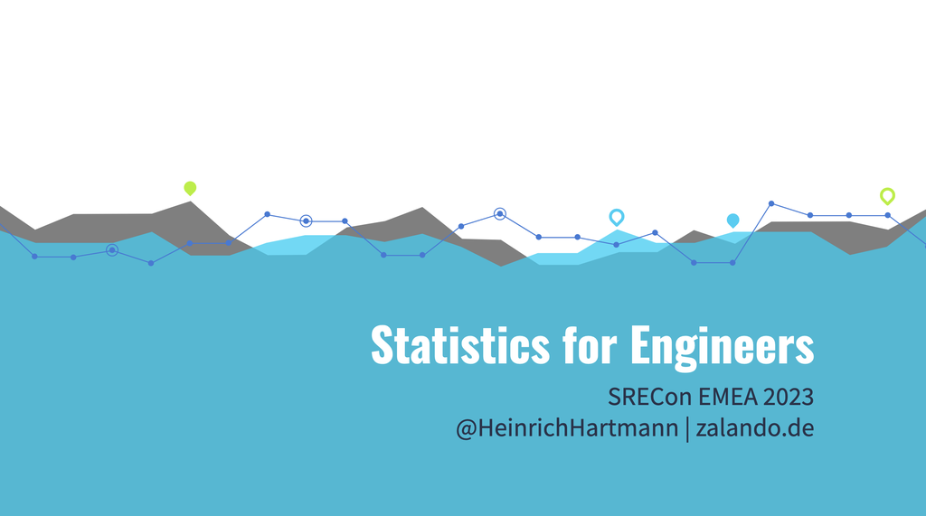

### Video

The Session at SRECon was not recorded. Here is a re-recording of the SLO parts.

```python
%%HTML
<!-- @CX-NO-INPUT -->
<iframe width="560" height="315" src="https://www.youtube.com/embed/upEvEgV_q48?si=EInKmQPcMXsq5lDH" title="YouTube video player" frameborder="0" allow="accelerometer; autoplay; clipboard-write; encrypted-media; gyroscope; picture-in-picture; web-share" allowfullscreen></iframe>
```

[video not shown]

```python
# @CX-CUTOFF
!pip -q install ipynbname
import ipynbname
nb_name = ipynbname.path().name
```

```python
%%script bash -s "$nb_name"
#
# Export Notebook as Blogpost
#
# WARNING: This will operate on the last saved version!
#
./render.sh "./$1" ./nb.html
cat <<EOF > fm.html
---
title: Statistics for Engineers @ SRECon EMEA 2023
date: 2023-10-15
tags: talk, post
url: /srecon-emea-2023
outputs:
  - RawHTML
---
EOF

cat fm.html nb.html > out.html
cp out.html "/host/root/home/hhartmann/src/HeinrichHartmann.github.io/hugo/content/posts/raw/srecon-emea-2023.html"
```

```
[NbConvertApp] Converting notebook ./2023-10-15 SREConEMEA 2023.ipynb to HTML
[NbConvertApp] Writing 1037948 bytes to nb.html
```